# STA141A Final Project: Predicting Mice Success from Neural Activities

Amanda Li

2024-03-18

## **Abstract**

Understanding the neural mechanisms underlying decision-making, action execution, and engagement with our environment is a fundamental pursuit in neuroscience. The interplay of neural circuits across various brain regions facilitates these cognitive processes, yet the specific principles that manage these complex behaviors remain cloudy. The study of animal models, particularly mice, has emerged as a powerful tool for probing the neural activity of behavior. In this project, I used data collected from Steinmetz et al. (2019) to predict the feedback type, or success of mice following trials of stimuli. Each mouse in the study was presented with visual stimuli and tasked with making directional decisions, prompting them to move the wheel in a specific direction corresponding to the visual cues. A reward and penalty system was implemented, contingent upon the accuracy of the mouse’s response to the visual stimuli. Rewards were given for correct movements and penalties were given for incorrect ones. The primary objective of this project is to develop a predictive model capable of predicting the outcomes of future sessions based on the data collected from observations involving these four mice. I first do this by performing Exploratory Data Analysis (EDA) to observe dynamics between the trials among each session. Next, I perform data integration to form a comprehensive dataset. My findings show that both logistic regression and decision trees yield similar results, with an accuracy hovering above 70%. However, when predicting unseen data, the logistic regression model performed 10% better than the decision tree. Thus, in the scope of my project, a logistic regression model is the most appropriate for this mice data.

## **1. Introduction**

The data source is derived from the paper “Distributed coding of choice, action, and engagement across the mouse brain” by Steinmetz et al. (2019). The target sample encompasses the 10 mice analyzed by Steinmetz, with a focus on 4 mice across 18 sessions, randomly sampled to reduce bias. The `feedback_type` variable assigns positive or negative scores based on mice’s wheel-turning responses to stimuli. `Left_contrast` and `right_contrast` denote the visual stimuli’s intensity, influencing wheel-turning direction. Time records neural activity spikes timing, while `spks` indicates brain activity intensity during the activity. `Brain_area` signifies the brain region involved, `mouse_name` specifies mouse identities, and `date_exp` records trial dates. Within this dataset, neural activity refers to patterns of electrical and biochemical occurrences within neurons, each linked to various facets of continuous decision-making, action selection, and task engagement. Moreover, the original experiment shows that the observation of neural activity is not confined to isolated regions of the brain but often involves stimulation across multiple brain areas.

The `feedback_type` variable reflects the outcome of the experiment, determining a positive or negative score based on whether the mice successfully turn the wheel in the correct direction in response to the stimuli presented. Meanwhile, the `left_contrast` variable denotes the intensity of the visual stimuli, taking values from the set {0, 0.25, 0.5, 1}, where 0 signifies the absence of stimuli and 1 represents a strong presence. Correspondingly, `right_contrast` mirrors `left_contrast`, encompassing the same range of values. If the `left_contrast` exceeds the `right_contrast`, the feedback_type is assigned a value of 1, indicating successful wheel turning to the right, while any other response results in a -1. Conversely, if the `right_contrast` surpasses the `left_contrast`, a feedback_type of 1 signifies successful wheel turning to the left, with -1 assigned for alternative responses. In cases where the contrasts are identical, one contrast is designated as correct. Furthermore, when both `left_contrast` and `right_contrast` are 0, successful completion of the task entails the mice holding the wheel still.

Several questions drive the analysis, including the difference in activated neurons between correct and incorrect responses to visual stimuli, common patterns across sessions, potential differences in neural activity between mice, and the effectiveness of the predictive model across various session data, along with the corresponding misclassification rate. Addressing these questions aims to provide meaningful insights into the dataset. A similar study conducted by Dr. Charles Findling (2023) on brain-wide representations of prior information in mouse decision-making provides recent and valuable insights for this analysis. His research, which utilized brain-wide neuropixels recordings and widefield calcium imaging performed by the International Brain Laboratory, focused on mice trained to detect the location of visual stimuli. These stimuli appeared either on the left or right, with prior probabilities alternating between 0.2 and 0.8 in variable-length blocks. Findling’s findings offer supplementary insights into mouse neural pathways, aligning well with the objectives of our predictive modeling efforts. By integrating these research findings with our analysis, we can further our understanding of mouse behavior and neural dynamics, ultimately enhancing the predictive modeling process.

All 18 Sessions

| mouse_name | date_exp | brain_area | neurons | trials | success_rate |
| --- | --- | --- | --- | --- | --- |
| Cori | 2016-12-14 | 8 | 734 | 114 | 0.61 |
| Cori | 2016-12-17 | 5 | 1070 | 251 | 0.63 |
| Cori | 2016-12-18 | 11 | 619 | 228 | 0.66 |
| Forssmann | 2017-11-01 | 11 | 1769 | 249 | 0.67 |
| Forssmann | 2017-11-02 | 10 | 1077 | 254 | 0.66 |
| Forssmann | 2017-11-04 | 5 | 1169 | 290 | 0.74 |
| Forssmann | 2017-11-05 | 8 | 584 | 252 | 0.67 |
| Hench | 2017-06-15 | 15 | 1157 | 250 | 0.64 |
| Hench | 2017-06-16 | 12 | 788 | 372 | 0.69 |
| Hench | 2017-06-17 | 13 | 1172 | 447 | 0.62 |
| Hench | 2017-06-18 | 6 | 857 | 342 | 0.80 |
| Lederberg | 2017-12-05 | 12 | 698 | 340 | 0.74 |
| Lederberg | 2017-12-06 | 15 | 983 | 300 | 0.80 |
| Lederberg | 2017-12-07 | 10 | 756 | 268 | 0.69 |
| Lederberg | 2017-12-08 | 8 | 743 | 404 | 0.76 |
| Lederberg | 2017-12-09 | 6 | 474 | 280 | 0.72 |
| Lederberg | 2017-12-10 | 6 | 565 | 224 | 0.83 |
| Lederberg | 2017-12-11 | 10 | 1090 | 216 | 0.81 |

**Figure 1**: Table representing all 18 mice sessions.

This table contains six variables, from left to right: the name of the mouse observed, the date of the session, the number of brain areas, neural spikes from each trial in the session, the number of trials in the session, and the average success rate (feedback) for the session.

## **2. Exploratory Data Analysis**

### 2.1 Descriptive Elements

71% of all trials are successful among all sessions. There are 62 distinct levels in the brain area.

### 2.2 EDA Figures

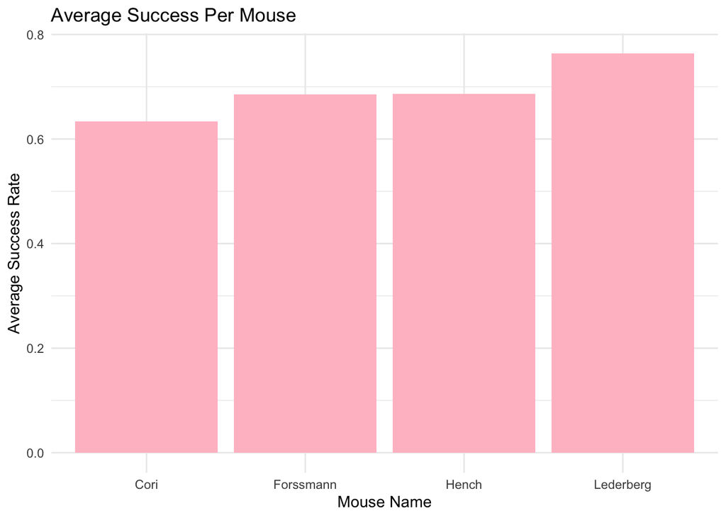

**Figure 2.2.1**: Average success rates across all four mice.

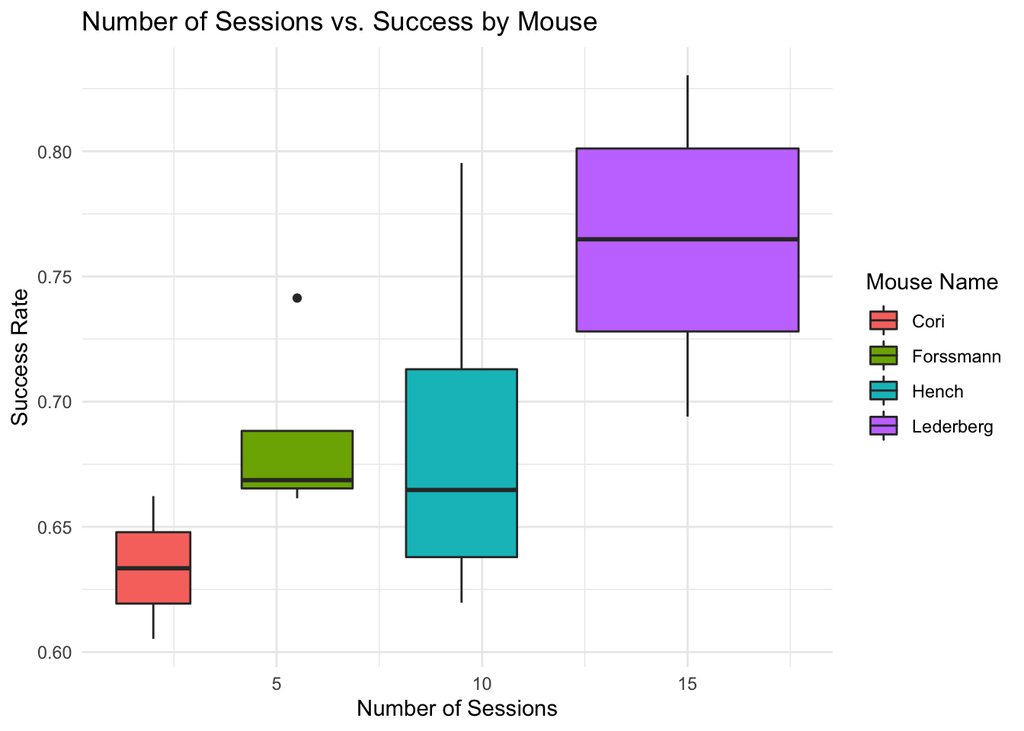

**Figure 2.2.2**: Number of sessions vs. success, by mouse.

```
##      CA1     POST     root     VISl    VISpm
## 1.121053 1.816754 1.538462 1.398268 2.000000
```

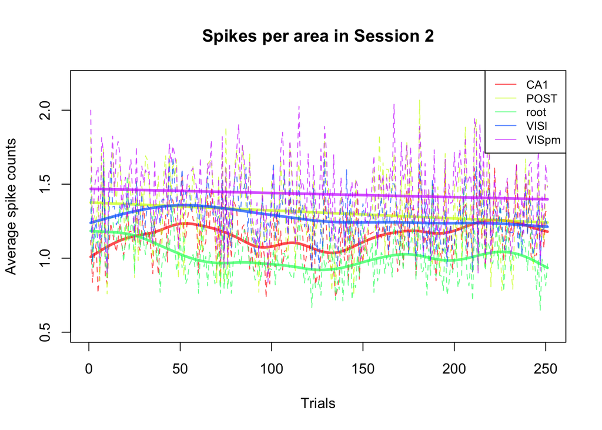

**Figure 2.2.3**: Average spike counts per trial in Session 2 (Cori).

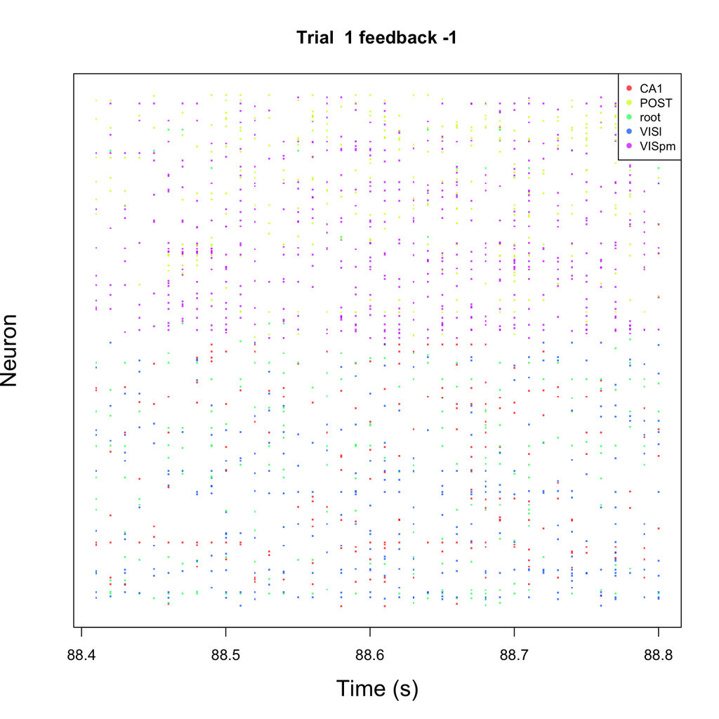

**Figure 2.2.4**: Raster plot for Trial 1 Feedback -1.

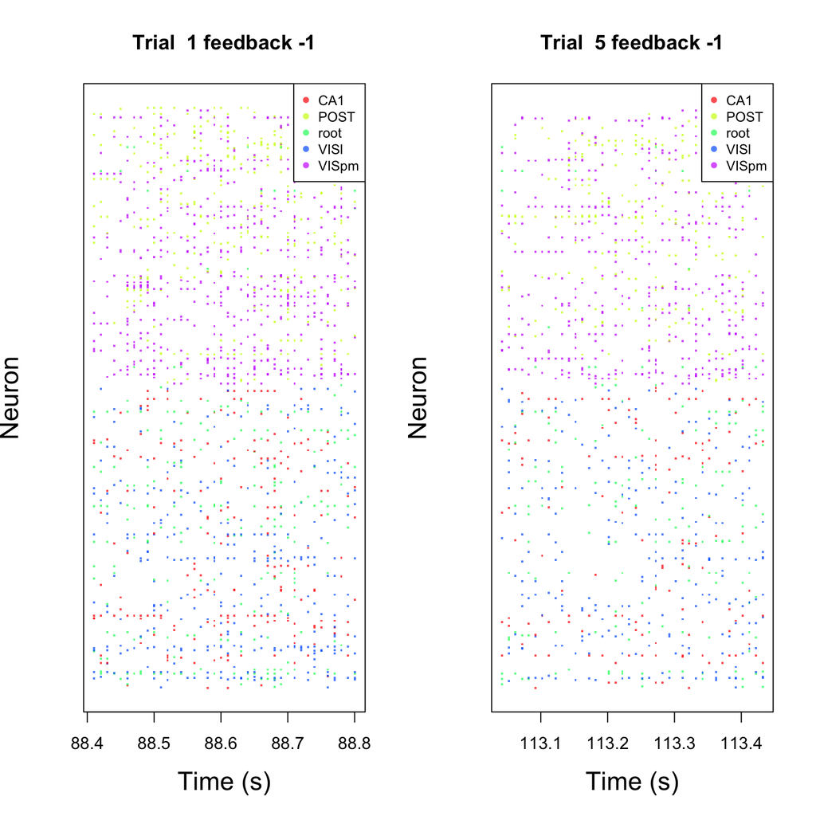

**Figure 2.2.5**: Raster plots for Trial 1 and 5, feedback -1.

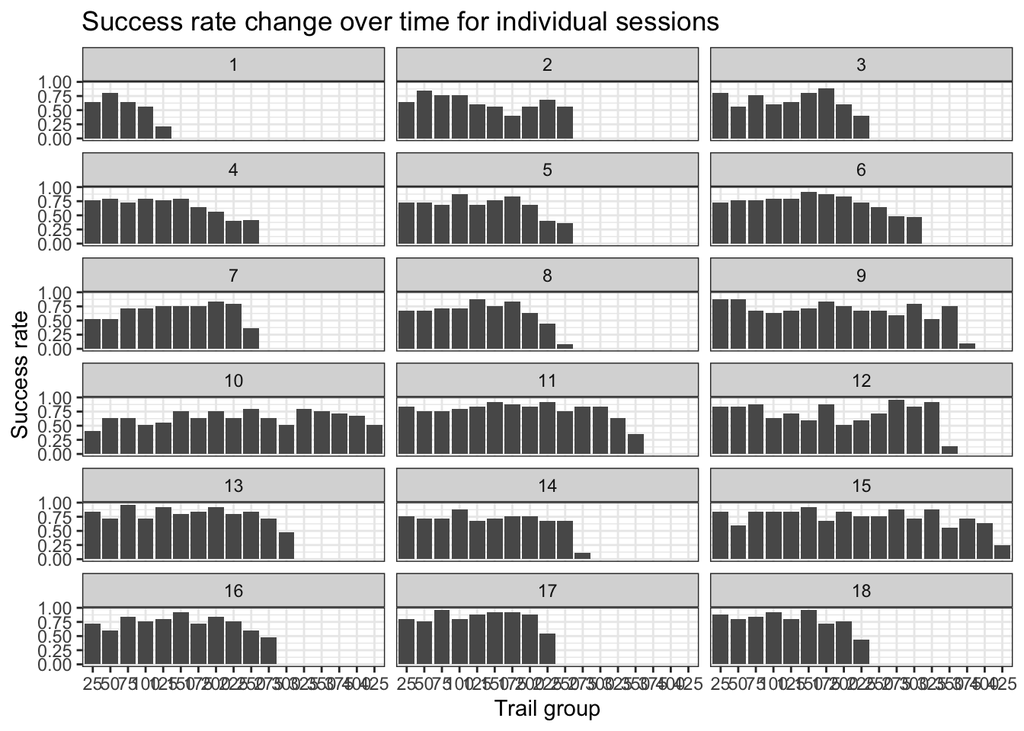

**Figure 2.2.6**: Change in success over time per session.

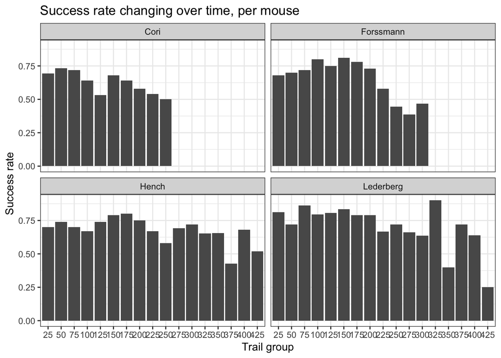

**Figure 2.2.7**: Change in success over time per mouse.

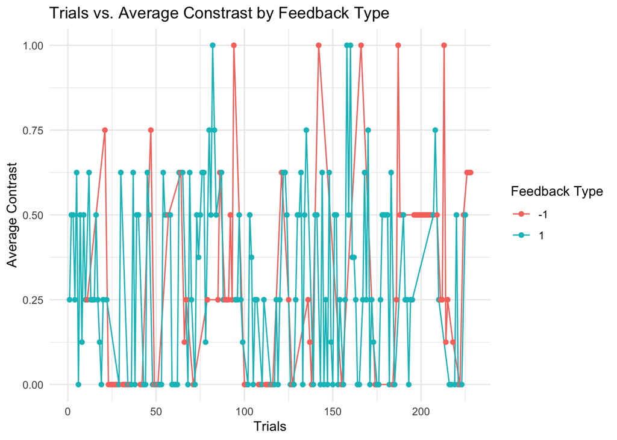

**Figure 2.2.8**: Average contrast as trials progress, by feedback type.

As the trials progress, noticeable differences emerge from the various feedback types. Specifically, in Session 3 with Cori the mouse, shifts occur between instances where the mouse fails to draw the correct feedback type and instances where it does. This offers valuable insights into the fluctuating average feedback success rate over the course of the trials. Furthermore, it shows the subtle variances in contrast levels across the entire session, hinting at patterns where the mouse correctly interprets the stimuli. From this, we can explore factors beyond visual stimuli leading to the success of the mouse.

## **3. Data Integration**

In order to pick the best model for predicting mice, we must first define the data set that will be used. To make this dataset, I merged every trial from each session into a master dataframe. This dataframe includes 5081 observations (total trials) and seven columns. The seven columns are session, `contrast_left`, `contrast_right`, `feedback_type`, `mouse_name`, `date_exp`, and `avg_spks_neuron.` By creating this comprehensive dataset, we have laid the groundwork for predictive modeling.

Dataset for Predictive Modeling: First 6 Observations

| session | contrast_left | contrast_right | feedback_type | mouse_name | date_exp | avg_spks_neuron |
| --- | --- | --- | --- | --- | --- | --- |
| Session 1 | 0.0 | 0.5 | 1 | Cori | 2016-12-14 | 1.58 |
| Session 1 | 0.0 | 0.0 | 1 | Cori | 2016-12-14 | 1.31 |
| Session 1 | 0.5 | 1.0 | -1 | Cori | 2016-12-14 | 1.84 |
| Session 1 | 0.0 | 0.0 | -1 | Cori | 2016-12-14 | 1.38 |
| Session 1 | 0.0 | 0.0 | -1 | Cori | 2016-12-14 | 1.43 |
| Session 1 | 0.0 | 0.0 | 1 | Cori | 2016-12-14 | 1.09 |

**Figure 3.1**: First six observations of the final dataset for predictive modeling.

## **4. Predictive Modeling**

My dataset contains categorical variables. I attempted two different models to predict `feedback_type`: logistic regression and decision trees. However, I did not use XGBoost. XGBoost is designed to work with numerical data efficiently. While it can handle categorical variables using techniques like one-hot encoding or ordinal encoding, these transformations introduce additional complexity and potential pitfalls, such as the curse of dimensionality or loss of information. Additionally, my R session would run very slowly, and my computer would start to burn up when I ran XGBoost. For these reasons, I decided not to use XGBoost in predictive modeling.

### 4.1 Logistic Regression (all variables)

We use the merged dataset to create a Logistic Regression model to predict `feedback_type`.

```
## [1] "Precision: 0.725158562367865"
```

```
## [1] "Recall: 0.950138504155125"
```

```
## [1] "F1 score: 0.822541966426859"
```

```
## [1] "Misclassification Error Rate: 0.291052114060964"
```

```
## [1] "Accuracy 0.708947885939036"
```

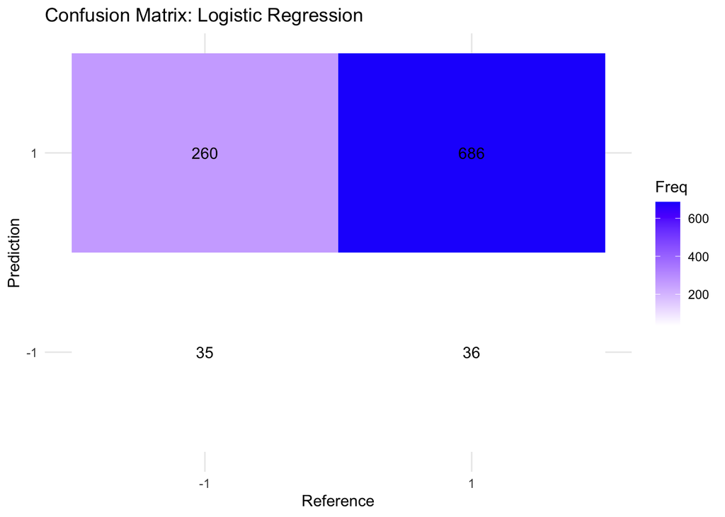

**Figure 4.1.1**: Confusion matrix for logistic regression.

Using Logistic Regression, we split the dataset into a training set and testing set, 0.8 and 0.2 of the original dataset respectively. The results are the following: precision is 72.51%, recall is 95.01%, and the F1 score is 0.8225 The misclassification error rate is approximately 29%. Precision is a measure of the accuracy of positive predictions made by a classifier. It is calculated as the ratio of true positive predictions to the sum of true positive and false positive predictions. Recall measures the ability of a classifier to find all the positive instances in the dataset. It is calculated as the ratio of true positive predictions to the sum of true positive and false negative predictions. The F1 score is the harmonic mean of precision and recall. It provides a single score that balances both precision and recall, making it a useful metric for evaluating classifiers, especially in situations where there is an imbalance between the classes. Lastly, the accuracy of this model hovers around 71%.

### 4.2 Decision Tree

```
## [1] "Precision: 0.740540540540541"
```

```
## [1] "Recall: 0.948753462603878"
```

```
## [1] "F1 score: 0.831815421979356"
```

```
## [1] "Misclassification Error Rate: 0.272369714847591"
```

```
## [1] "Accuracy 0.727630285152409"
```

Using a Decision Tree, we split the dataset into a training set and testing set, 0.8 and 0.2 of the original dataset respectively. A decision tree is a flowchart-like structure where an internal node represents a feature (or attribute), the branch represents a decision rule, and each leaf node represents an outcome or class label. The results are as follows: precision is 74.05%, recall is 94.87%, and the F1 score is 0.8318. The misclassification error rate is 27.24%, and the accuracy of the decision tree model is 72.76%. Although the difference is marginal, the decision tree performs slightly better compared to logistic regression, by about 1%.

## **5. Prediction Performance**

### 5.1 Logistic Regression Test

```
## [1] "Precision: 0.767295597484277"
```

```
## [1] "Recall: 0.841379310344828"
```

```
## [1] "F1 score: 0.802631578947368"
```

```
## [1] "Misclassification Error Rate: 0.3"
```

```
## [1] "Accuracy: 0.7"
```

Because my model was trained on a specific format of a dataset, I merged the test data sets together in a similar format. Predicting using the logistic regression model, the results are as follows: precision is 76.73%, recall is 84.14%, and the F1 score is 0.8026. The accuracy is exactly 70%, meaning that the misclassification error rate is 30%. Our test accuracy using this new dataset appears to follow similar trends as the original accuracy of the model using 0.2 test data. From this, I consider this logistic regression model to be a reasonable predictor for `feedback_type`.

### 5.2 Decision Tree Test

```
## [1] "Precision: 0.746268656716418"
```

```
## [1] "Recall: 0.689655172413793"
```

```
## [1] "F1 score: 0.716845878136201"
```

```
## [1] "Misclassification Error Rate: 0.395"
```

```
## [1] "Accuracy: 0.605"
```

Predicting using the decision tree model, the results are as follows: precision is 74.65%, recall is 68.97%, and F1 score is 0.7168. The accuracy is 0.605 and the misclassification error rate is 0.395. Interestingly, the decision tree was the best choice using the 0.8/0.2 split data, yet it performed 10% worse in accuracy when this new test data was introduced. On the other hand, the logistic regression model accuracy remained relatively the same despite the new data.

### 5.3 Final Model

From my results using the test data, I have chosen logistic regression to be the most robust model in the scope of this project. The logistic regression model had an accuracy of 70%, while the decision tree model had an accuracy of 60.5% (decrease by 10%). There may be several reasons for the decrease in accuracy in my decision tree model. Logistic regression can be effective when dealing with datasets with a small number of features or when feature interactions are limited. Decision trees may struggle to generalize well in high-dimensional spaces or when there are many features, leading to overfitting or poor generalization. Additionally, logistic regression models are inherently more interpretable than decision trees. In some cases, the simplicity of logistic regression models may lead to better accuracy because it’s easier to understand and identify the most relevant features for prediction.

## **6. Discussion**

In my predictive models, I used logistic regression as well as a decision tree. Both utilized the dataset I had created during data integration, which only represented seven variables. In the future, I would like to utilize the brain area data as well. This was not included in my data integration, due to its complexity. Additionally, I would like to try using XGBoost to predict feedback type. I decided not to use XGBoost because it performs better on numeric data. My dataset contains categorical variables. Overall, this project was very comprehensive and I had the opportunity to learn more about statistical data science by working with this unique dataset.

## **Appendix**

I used the boilerplate code provided by the consulting sessions and the TA discussions. I used ChatGPT to brainstorm predictive modeling methods, alter the boilerplate code provided by the course, and edit my research report.

Findling, C., Hubert, F., Acerbi, L., Benson, B., Benson, J., Birman, D., Bonacchi, N., Carandini, M., Catarino, J. A., Chapuis, G. A., Churchland, A. K., Dan, Y., DeWitt, E. E., Engel, T. A., Fabbri, M., Faulkner, M., Fiete, I. R., Freitas-Silva, L., Gerçek, B., … Pouget, A. (2023). Brain-wide representations of prior information in mouse decision-making. Cold Spring Harbor Laboratory. http://dx.doi.org/10.1101/2023.07.04.547684

Steinmetz, N.A., Zatka-Haas, P., Carandini, M. et al. Distributed coding of choice, action and engagement across the mouse brain. Nature 576, 266–273 (2019). https://doi.org/10.1038/s41586-019-1787-x